# Project 4 Ensemble Techniques-JStatter (1)

#### Travel Package Purchase Prediction - Problem Statement

Description Background and Context

You are a Data Scientist for a tourism company named "Visit with us". The Policy Maker of the company wants to enable and establish a viable business model to expand the customer base.

A viable business model is a central concept that helps you to understand the existing ways of doing the business and how to change the ways for the benefit of the tourism sector.

One of the ways to expand the customer base is to introduce a new offering of packages.

Currently, there are 5 types of packages the company is offering - Basic, Standard, Deluxe, Super Deluxe, King. Looking at the data of the last year, we observed that 18% of the customers purchased the packages.

However, the marketing cost was quite high because customers were contacted at random without looking at the available information.

The company is now planning to launch a new product i.e. Wellness Tourism Package. Wellness Tourism is defined as Travel that allows the traveler to maintain, enhance or kick-start a healthy lifestyle, and support or increase one's sense of well-being.

However, this time company wants to harness the available data of existing and potential customers to make the marketing expenditure more efficient.

You as a Data Scientist at "Visit with us" travel company have to analyze the customers' data and information to provide recommendations to the Policy Maker and Marketing Team and also build a model to predict the potential customer who is going to purchase the newly introduced travel package.

Objective

To predict which customer is more likely to purchase the newly introduced travel package.

Data Dictionary

Customer details:

CustomerID: Unique customer ID ProdTaken: Whether the customer has purchased a package or not (0: No, 1: Yes) Age: Age of customer TypeofContact: How customer was contacted (Company Invited or Self Inquiry) CityTier: City tier depends on the development of a city, population, facilities, and living standards. The categories are ordered i.e. Tier 1 > Tier 2 > Tier 3 Occupation: Occupation of customer Gender: Gender of customer NumberOfPersonVisiting: Total number of persons planning to take the trip with the customer PreferredPropertyStar: Preferred hotel property rating by customer MaritalStatus: Marital status of customer NumberOfTrips: Average number of trips in a year by customer Passport: The customer has a passport or not (0: No, 1: Yes) OwnCar: Whether the customers own a car or not (0: No, 1: Yes) NumberOfChildrenVisiting: Total number of children with age less than 5 planning to take the trip with the customer Designation: Designation of the customer in the current organization MonthlyIncome: Gross monthly income of the customer Customer interaction data:

PitchSatisfactionScore: Sales pitch satisfaction score ProductPitched: Product pitched by the salesperson NumberOfFollowups: Total number of follow-ups has been done by the salesperson after the sales pitch DurationOfPitch: Duration of the pitch by a salesperson to the customer

Note:

Please note XGBoost can take a significantly longer time to run, so if you have time complexity issues then you can avoid tuning XGBoost. No marks will be deducted if XGBoost tuning is not attempted.

### Libaries:

```python
# Library to suppress warnings or deprecation notes
import warnings
warnings.filterwarnings('ignore')

# Libraries to help with reading and manipulating data
import numpy as np
import pandas as pd

# Libraries to help with data visualization
import matplotlib.pyplot as plt
%matplotlib inline
import seaborn as sns

# Libraries to split data, impute missing values
from sklearn.model_selection import train_test_split
from sklearn.impute import SimpleImputer

# Libraries to import decision tree classifier and different ensemble classifiers
from sklearn.ensemble import BaggingClassifier
from sklearn.ensemble import RandomForestClassifier
from sklearn.ensemble import AdaBoostClassifier, GradientBoostingClassifier
from xgboost import XGBClassifier
from sklearn.tree import DecisionTreeRegressor
from sklearn.ensemble import BaggingRegressor,RandomForestRegressor, GradientBoostingRegressor, AdaBoostRegressor, StackingRegressor
from xgboost import XGBRegressor
from sklearn.ensemble import StackingClassifier
from sklearn.tree import DecisionTreeClassifier

# Libtune to tune model, get different metric scores
from sklearn import metrics
from sklearn.metrics import confusion_matrix, classification_report, accuracy_score, precision_score, recall_score, f1_score, roc_auc_score
import scipy.stats as stats
from sklearn import tree
from sklearn.model_selection import GridSearchCV
from sklearn.linear_model import LogisticRegression
```

```python
customer = pd.read_csv('Tourism.csv')
```

```python
data =customer.copy()
```

```python
data.head()
```

|  | CustomerID | ProdTaken | Age | TypeofContact | CityTier | DurationOfPitch | Occupation | Gender | NumberOfPersonVisiting | NumberOfFollowups | ProductPitched | PreferredPropertyStar | MaritalStatus | NumberOfTrips | Passport | PitchSatisfactionScore | OwnCar | NumberOfChildrenVisiting | Designation | MonthlyIncome |
| --- | --- | --- | --- | --- | --- | --- | --- | --- | --- | --- | --- | --- | --- | --- | --- | --- | --- | --- | --- | --- |
| 0 | 200000 | 1 | 41.0 | Self Enquiry | 3 | 6.0 | Salaried | Female | 3 | 3.0 | Deluxe | 3.0 | Single | 1.0 | 1 | 2 | 1 | 0.0 | Manager | 20993.0 |
| 1 | 200001 | 0 | 49.0 | Company Invited | 1 | 14.0 | Salaried | Male | 3 | 4.0 | Deluxe | 4.0 | Divorced | 2.0 | 0 | 3 | 1 | 2.0 | Manager | 20130.0 |
| 2 | 200002 | 1 | 37.0 | Self Enquiry | 1 | 8.0 | Free Lancer | Male | 3 | 4.0 | Basic | 3.0 | Single | 7.0 | 1 | 3 | 0 | 0.0 | Executive | 17090.0 |
| 3 | 200003 | 0 | 33.0 | Company Invited | 1 | 9.0 | Salaried | Female | 2 | 3.0 | Basic | 3.0 | Divorced | 2.0 | 1 | 5 | 1 | 1.0 | Executive | 17909.0 |
| 4 | 200004 | 0 | NaN | Self Enquiry | 1 | 8.0 | Small Business | Male | 2 | 3.0 | Basic | 4.0 | Divorced | 1.0 | 0 | 5 | 1 | 0.0 | Executive | 18468.0 |

```python
data.tail()
```

|  | CustomerID | ProdTaken | Age | TypeofContact | CityTier | DurationOfPitch | Occupation | Gender | NumberOfPersonVisiting | NumberOfFollowups | ProductPitched | PreferredPropertyStar | MaritalStatus | NumberOfTrips | Passport | PitchSatisfactionScore | OwnCar | NumberOfChildrenVisiting | Designation | MonthlyIncome |
| --- | --- | --- | --- | --- | --- | --- | --- | --- | --- | --- | --- | --- | --- | --- | --- | --- | --- | --- | --- | --- |
| 4883 | 204883 | 1 | 49.0 | Self Enquiry | 3 | 9.0 | Small Business | Male | 3 | 5.0 | Deluxe | 4.0 | Unmarried | 2.0 | 1 | 1 | 1 | 1.0 | Manager | 26576.0 |
| 4884 | 204884 | 1 | 28.0 | Company Invited | 1 | 31.0 | Salaried | Male | 4 | 5.0 | Basic | 3.0 | Single | 3.0 | 1 | 3 | 1 | 2.0 | Executive | 21212.0 |
| 4885 | 204885 | 1 | 52.0 | Self Enquiry | 3 | 17.0 | Salaried | Female | 4 | 4.0 | Standard | 4.0 | Married | 7.0 | 0 | 1 | 1 | 3.0 | Senior Manager | 31820.0 |
| 4886 | 204886 | 1 | 19.0 | Self Enquiry | 3 | 16.0 | Small Business | Male | 3 | 4.0 | Basic | 3.0 | Single | 3.0 | 0 | 5 | 0 | 2.0 | Executive | 20289.0 |
| 4887 | 204887 | 1 | 36.0 | Self Enquiry | 1 | 14.0 | Salaried | Male | 4 | 4.0 | Basic | 4.0 | Unmarried | 3.0 | 1 | 3 | 1 | 2.0 | Executive | 24041.0 |

```python
data.shape
```

```
(4888, 20)
```

```python
data.info()
```

```
<class 'pandas.core.frame.DataFrame'>
RangeIndex: 4888 entries, 0 to 4887
Data columns (total 20 columns):
 #   Column                    Non-Null Count  Dtype
---  ------                    --------------  -----
 0   CustomerID                4888 non-null   int64
 1   ProdTaken                 4888 non-null   int64
 2   Age                       4662 non-null   float64
 3   TypeofContact             4863 non-null   object
 4   CityTier                  4888 non-null   int64
 5   DurationOfPitch           4637 non-null   float64
 6   Occupation                4888 non-null   object
 7   Gender                    4888 non-null   object
 8   NumberOfPersonVisiting    4888 non-null   int64
 9   NumberOfFollowups         4843 non-null   float64
 10  ProductPitched            4888 non-null   object
 11  PreferredPropertyStar     4862 non-null   float64
 12  MaritalStatus             4888 non-null   object
 13  NumberOfTrips             4748 non-null   float64
 14  Passport                  4888 non-null   int64
 15  PitchSatisfactionScore    4888 non-null   int64
 16  OwnCar                    4888 non-null   int64
 17  NumberOfChildrenVisiting  4822 non-null   float64
 18  Designation               4888 non-null   object
 19  MonthlyIncome             4655 non-null   float64
dtypes: float64(7), int64(7), object(6)
memory usage: 763.9+ KB
```

### Data Clean Up

#### Checking for any duplicates:

```python
data[data.duplicated()].count()
```

```
CustomerID                  0
ProdTaken                   0
Age                         0
TypeofContact               0
CityTier                    0
DurationOfPitch             0
Occupation                  0
Gender                      0
NumberOfPersonVisiting      0
NumberOfFollowups           0
ProductPitched              0
PreferredPropertyStar       0
MaritalStatus               0
NumberOfTrips               0
Passport                    0
PitchSatisfactionScore      0
OwnCar                      0
NumberOfChildrenVisiting    0
Designation                 0
MonthlyIncome               0
dtype: int64
```

- There are no duplicates.

#### Dropping Columns and Editing Rows:

```python
# checking for missing values in the data
data.isnull().sum()
```

```
CustomerID                    0
ProdTaken                     0
Age                         226
TypeofContact                25
CityTier                      0
DurationOfPitch             251
Occupation                    0
Gender                        0
NumberOfPersonVisiting        0
NumberOfFollowups            45
ProductPitched                0
PreferredPropertyStar        26
MaritalStatus                 0
NumberOfTrips               140
Passport                      0
PitchSatisfactionScore        0
OwnCar                        0
NumberOfChildrenVisiting     66
Designation                   0
MonthlyIncome               233
dtype: int64
```

##### Female and Fe Male:

```python
data = data[data.Gender != "Fe Male"]
```

```python
data["Gender"].nunique()
```

```
2
```

##### Droping CustomerID:

```python
data=data.dropna()
```

```python
# drop the CustomerID. column as it does not add any value to the analysis
data.drop("CustomerID", axis=1, inplace=True)
```

```python
data.shape
```

```
(3973, 19)
```

```python
# checking for missing values in the data
data.isnull().sum()
```

```
ProdTaken                   0
Age                         0
TypeofContact               0
CityTier                    0
DurationOfPitch             0
Occupation                  0
Gender                      0
NumberOfPersonVisiting      0
NumberOfFollowups           0
ProductPitched              0
PreferredPropertyStar       0
MaritalStatus               0
NumberOfTrips               0
Passport                    0
PitchSatisfactionScore      0
OwnCar                      0
NumberOfChildrenVisiting    0
Designation                 0
MonthlyIncome               0
dtype: int64
```

- Na values were removed.
- Customer ID was removed.

#### Categorical Data:

##### Listing non-numeric Columns:

```python
# filtering non-numeric columns
cat_columns = data.select_dtypes(exclude=np.number).columns
cat_columns
```

```
Index(['TypeofContact', 'Occupation', 'Gender', 'ProductPitched',
       'MaritalStatus', 'Designation'],
      dtype='object')
```

```python
## Converting the data type of categorical features to 'category'
cat_cols = [
    'TypeofContact', 'Occupation', 'Gender', 'ProductPitched',
       'MaritalStatus', 'Designation'
]
```

```python
data[cat_cols].nunique()
```

```
TypeofContact     2
Occupation        4
Gender            2
ProductPitched    5
MaritalStatus     4
Designation       5
dtype: int64
```

```python
data[cat_cols] = data[cat_cols].astype("category")
data.info()
```

```
<class 'pandas.core.frame.DataFrame'>
Int64Index: 3973 entries, 0 to 4887
Data columns (total 19 columns):
 #   Column                    Non-Null Count  Dtype
---  ------                    --------------  -----
 0   ProdTaken                 3973 non-null   int64
 1   Age                       3973 non-null   float64
 2   TypeofContact             3973 non-null   category
 3   CityTier                  3973 non-null   int64
 4   DurationOfPitch           3973 non-null   float64
 5   Occupation                3973 non-null   category
 6   Gender                    3973 non-null   category
 7   NumberOfPersonVisiting    3973 non-null   int64
 8   NumberOfFollowups         3973 non-null   float64
 9   ProductPitched            3973 non-null   category
 10  PreferredPropertyStar     3973 non-null   float64
 11  MaritalStatus             3973 non-null   category
 12  NumberOfTrips             3973 non-null   float64
 13  Passport                  3973 non-null   int64
 14  PitchSatisfactionScore    3973 non-null   int64
 15  OwnCar                    3973 non-null   int64
 16  NumberOfChildrenVisiting  3973 non-null   float64
 17  Designation               3973 non-null   category
 18  MonthlyIncome             3973 non-null   float64
dtypes: category(6), float64(7), int64(6)
memory usage: 458.9 KB
```

```python
data[cat_cols].nunique()
```

```
TypeofContact     2
Occupation        4
Gender            2
ProductPitched    5
MaritalStatus     4
Designation       5
dtype: int64
```

```python
data[cat_cols].head()
```

|  | TypeofContact | Occupation | Gender | ProductPitched | MaritalStatus | Designation |
| --- | --- | --- | --- | --- | --- | --- |
| 0 | Self Enquiry | Salaried | Female | Deluxe | Single | Manager |
| 1 | Company Invited | Salaried | Male | Deluxe | Divorced | Manager |
| 2 | Self Enquiry | Free Lancer | Male | Basic | Single | Executive |
| 3 | Company Invited | Salaried | Female | Basic | Divorced | Executive |
| 5 | Company Invited | Salaried | Male | Basic | Single | Executive |

#### Replacing TypeofContact:

```python
data['TypeofContact'].nunique()
```

```
2
```

```python
data['TypeofContact'].astype("bool")
```

```
0       True
1       True
2       True
3       True
5       True
        ...
4883    True
4884    True
4885    True
4886    True
4887    True
Name: TypeofContact, Length: 3973, dtype: bool
```

```python
# let us reset the dataframe index
data.reset_index(inplace=True, drop=True)
```

```python
data.describe(include=["category"]).T
```

|  | count | unique | top | freq |
| --- | --- | --- | --- | --- |
| TypeofContact | 3973 | 2 | Self Enquiry | 2823 |
| Occupation | 3973 | 4 | Salaried | 1934 |
| Gender | 3973 | 2 | Male | 2463 |
| ProductPitched | 3973 | 5 | Basic | 1611 |
| MaritalStatus | 3973 | 4 | Married | 1990 |
| Designation | 3973 | 5 | Executive | 1611 |

```python
data.info()
```

```
<class 'pandas.core.frame.DataFrame'>
RangeIndex: 3973 entries, 0 to 3972
Data columns (total 19 columns):
 #   Column                    Non-Null Count  Dtype
---  ------                    --------------  -----
 0   ProdTaken                 3973 non-null   int64
 1   Age                       3973 non-null   float64
 2   TypeofContact             3973 non-null   category
 3   CityTier                  3973 non-null   int64
 4   DurationOfPitch           3973 non-null   float64
 5   Occupation                3973 non-null   category
 6   Gender                    3973 non-null   category
 7   NumberOfPersonVisiting    3973 non-null   int64
 8   NumberOfFollowups         3973 non-null   float64
 9   ProductPitched            3973 non-null   category
 10  PreferredPropertyStar     3973 non-null   float64
 11  MaritalStatus             3973 non-null   category
 12  NumberOfTrips             3973 non-null   float64
 13  Passport                  3973 non-null   int64
 14  PitchSatisfactionScore    3973 non-null   int64
 15  OwnCar                    3973 non-null   int64
 16  NumberOfChildrenVisiting  3973 non-null   float64
 17  Designation               3973 non-null   category
 18  MonthlyIncome             3973 non-null   float64
dtypes: category(6), float64(7), int64(6)
memory usage: 428.0 KB
```

#### Data Summary:

```python
data.describe().T
```

|  | count | mean | std | min | 25% | 50% | 75% | max |
| --- | --- | --- | --- | --- | --- | --- | --- | --- |
| ProdTaken | 3973.0 | 0.194312 | 0.395720 | 0.0 | 0.0 | 0.0 | 0.0 | 1.0 |
| Age | 3973.0 | 37.186006 | 9.217736 | 18.0 | 30.0 | 36.0 | 43.0 | 61.0 |
| CityTier | 3973.0 | 1.651900 | 0.916116 | 1.0 | 1.0 | 1.0 | 3.0 | 3.0 |
| DurationOfPitch | 3973.0 | 15.603826 | 8.413717 | 5.0 | 9.0 | 14.0 | 21.0 | 127.0 |
| NumberOfPersonVisiting | 3973.0 | 2.946136 | 0.720243 | 1.0 | 2.0 | 3.0 | 3.0 | 5.0 |
| NumberOfFollowups | 3973.0 | 3.734206 | 1.007939 | 1.0 | 3.0 | 4.0 | 4.0 | 6.0 |
| PreferredPropertyStar | 3973.0 | 3.581928 | 0.795028 | 3.0 | 3.0 | 3.0 | 4.0 | 5.0 |
| NumberOfTrips | 3973.0 | 3.278379 | 1.846863 | 1.0 | 2.0 | 3.0 | 4.0 | 22.0 |
| Passport | 3973.0 | 0.295998 | 0.456548 | 0.0 | 0.0 | 0.0 | 1.0 | 1.0 |
| PitchSatisfactionScore | 3973.0 | 3.064435 | 1.359342 | 1.0 | 2.0 | 3.0 | 4.0 | 5.0 |
| OwnCar | 3973.0 | 0.608860 | 0.488067 | 0.0 | 0.0 | 1.0 | 1.0 | 1.0 |
| NumberOfChildrenVisiting | 3973.0 | 1.220740 | 0.854378 | 0.0 | 1.0 | 1.0 | 2.0 | 3.0 |
| MonthlyIncome | 3973.0 | 23084.806695 | 4558.420282 | 1000.0 | 20706.0 | 22163.0 | 25169.0 | 98678.0 |

## EDA

### Univariate analysis

```python
# function to plot a boxplot and a histogram along the same scale.


def histogram_boxplot(data, feature, figsize=(12, 7), kde=False, bins=None):
    """
    Boxplot and histogram combined

    data: dataframe
    feature: dataframe column
    figsize: size of figure (default (12,7))
    kde: whether to show the density curve (default False)
    bins: number of bins for histogram (default None)
    """
    f2, (ax_box2, ax_hist2) = plt.subplots(
        nrows=2,  # Number of rows of the subplot grid= 2
        sharex=True,  # x-axis will be shared among all subplots
        gridspec_kw={"height_ratios": (0.25, 0.75)},
        figsize=figsize,
    )  # creating the 2 subplots
    sns.boxplot(
        data=data, x=feature, ax=ax_box2, showmeans=True, color="violet"
    )  # boxplot will be created and a star will indicate the mean value of the column
    sns.histplot(
        data=data, x=feature, kde=kde, ax=ax_hist2, bins=bins, palette="winter"
    ) if bins else sns.histplot(
        data=data, x=feature, kde=kde, ax=ax_hist2
    )  # For histogram
    ax_hist2.axvline(
        data[feature].mean(), color="green", linestyle="--"
    )  # Add mean to the histogram
    ax_hist2.axvline(
        data[feature].median(), color="black", linestyle="-"
    )  # Add median to the histogram
```

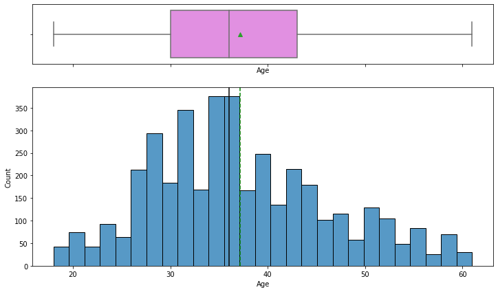

```python
histogram_boxplot(data,'Age')
```

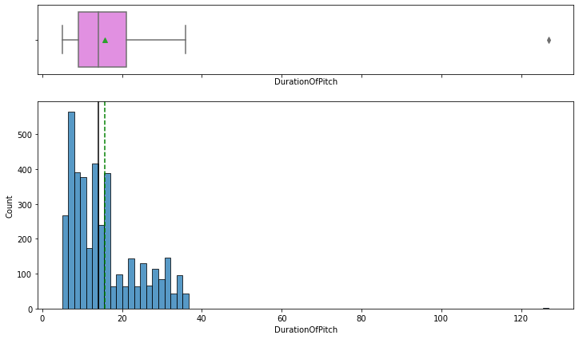

```python
histogram_boxplot(data,'DurationOfPitch')
```

- Has a outliar

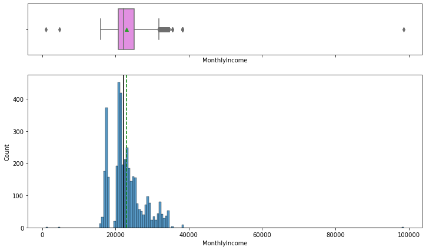

```python
histogram_boxplot(data,'MonthlyIncome')
```

- Has a outliar

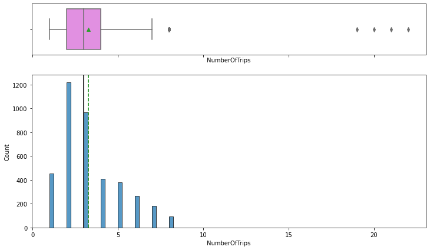

```python
histogram_boxplot(data,'NumberOfTrips')
```

- right scewed

```python
# function to create labeled barplots


def labeled_barplot(data, feature, perc=False, n=None):
    """
    Barplot with percentage at the top

    data: dataframe
    feature: dataframe column
    perc: whether to display percentages instead of count (default is False)
    n: displays the top n category levels (default is None, i.e., display all levels)
    """

    total = len(data[feature])  # length of the column
    count = data[feature].nunique()
    if n is None:
        plt.figure(figsize=(count + 1, 5))
    else:
        plt.figure(figsize=(n + 1, 5))

    plt.xticks(rotation=90, fontsize=15)
    ax = sns.countplot(
        data=data,
        x=feature,
        palette="Paired",
        order=data[feature].value_counts().index[:n].sort_values(),
    )

    for p in ax.patches:
        if perc == True:
            label = "{:.1f}%".format(
                100 * p.get_height() / total
            )  # percentage of each class of the category
        else:
            label = p.get_height()  # count of each level of the category

        x = p.get_x() + p.get_width() / 2  # width of the plot
        y = p.get_height()  # height of the plot

        ax.annotate(
            label,
            (x, y),
            ha="center",
            va="center",
            size=12,
            xytext=(0, 5),
            textcoords="offset points",
        )  # annotate the percentage

    plt.show()  # show the plot
```

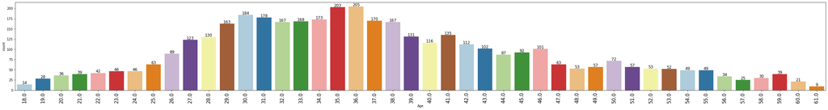

```python
labeled_barplot(data,'Age')
```

- most clients are between 27 and 40.

#### Categories:

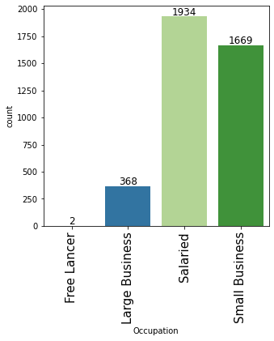

```python
labeled_barplot(data,'Occupation')
```

- Most clients are salaried with a small business in second place.

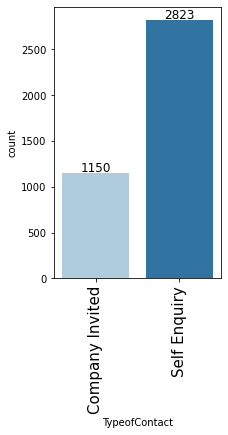

```python
labeled_barplot(data,'TypeofContact')
```

- Most clients are do self enquiry.

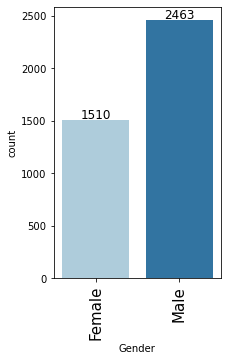

```python
labeled_barplot(data,"Gender")
```

- There are more male clients. I will approach the female vs male purchasing habits by percentage rather than by amount to avoid bias.

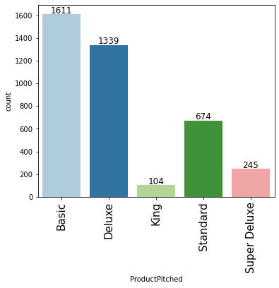

```python
labeled_barplot(data,"ProductPitched")
```

- The basic package was pitched the most.

### Bivariate Analysis:

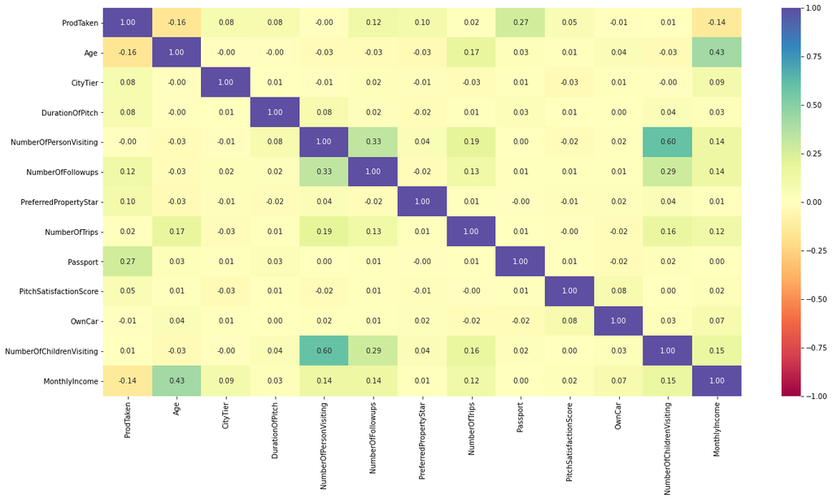

```python
plt.figure(figsize=(20,10))
sns.heatmap(data.corr(),annot=True,vmin=-1,vmax=1,fmt='.2f',cmap="Spectral")
plt.show()
```

- Passport has the only notible positive correlation with ProdTaken.
- Passport has no strong correlations with any other traits.

##### CityTier vs. NumberOfFollowups vs.PreferredPropertyStar Effect on Passport

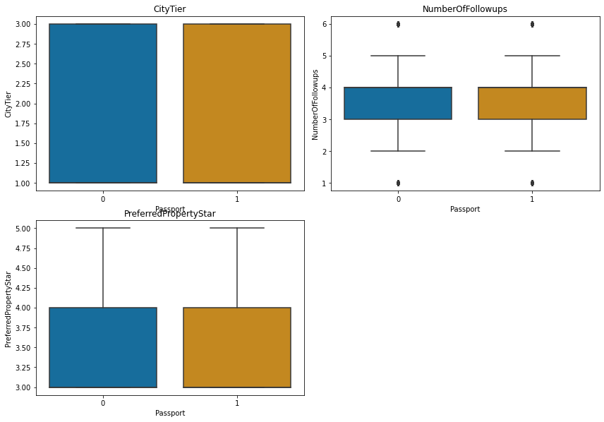

```python
cols = data[['CityTier', 'NumberOfFollowups','PreferredPropertyStar']].columns.tolist()
plt.figure(figsize=(12,12))

for i, variable in enumerate(cols):
                     plt.subplot(3,2,i+1)
                     sns.boxplot(data['Passport'],data[variable],palette="colorblind")
                     plt.tight_layout()
                     plt.title(variable)
plt.show()
```

- All of these traits have little to do with passport.

##### Stacked Bar Plot:

```python
# function to plot stacked bar chart


def stacked_barplot(data, predictor, target):
    """
    Print the category counts and plot a stacked bar chart

    data: dataframe
    predictor: independent variable
    target: target variable
    """
    count = data[predictor].nunique()
    sorter = data[target].value_counts().index[-1]
    tab1 = pd.crosstab(data[predictor], data[target], margins=True).sort_values(
        by=sorter, ascending=False
    )
    print(tab1)
    print("-" * 120)
    tab = pd.crosstab(data[predictor], data[target], normalize="index").sort_values(
        by=sorter, ascending=False
    )
    tab.plot(kind="bar", stacked=True, figsize=(count + 1, 5))
    plt.legend(
        loc="lower left",
        frameon=False,
    )
    plt.legend(loc="upper left", bbox_to_anchor=(1, 1))
    plt.show()
```

```
ProductPitched  Basic  Deluxe  King  Standard  Super Deluxe   All
ProdTaken
All              1611    1339   104       674           245  3973
0                1129    1189    95       560           228  3201
1                 482     150     9       114            17   772
------------------------------------------------------------------------------------------------------------------------
```

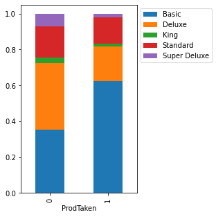

```python
stacked_barplot(data, "ProdTaken", "ProductPitched")
```

- Basic was pitched the most so as expected it sold the best.
- The pattern of pitching is well correlated with if a product was purchased.

### Summary of EDA:

- Passport has the highest Correlation with ProdTaken.
- Basic was pitched the most so as expected it sold the best.
- The pattern of pitching is well correlated with if a product was purchased.

## Building Model:

#### Spliting Dataframe:

```python
X = data.drop("ProdTaken" , axis=1)
y = data.pop("ProdTaken")
```

```python
# I am creating dummies for test data
X = pd.get_dummies(
    X,
    columns=X.select_dtypes(include=["object", "category"]).columns.tolist(),
    drop_first=True,
)

X.head()
```

|  | Age | CityTier | DurationOfPitch | NumberOfPersonVisiting | NumberOfFollowups | PreferredPropertyStar | NumberOfTrips | Passport | PitchSatisfactionScore | OwnCar | ... | ProductPitched_King | ProductPitched_Standard | ProductPitched_Super Deluxe | MaritalStatus_Married | MaritalStatus_Single | MaritalStatus_Unmarried | Designation_Executive | Designation_Manager | Designation_Senior Manager | Designation_VP |
| --- | --- | --- | --- | --- | --- | --- | --- | --- | --- | --- | --- | --- | --- | --- | --- | --- | --- | --- | --- | --- | --- |
| 0 | 41.0 | 3 | 6.0 | 3 | 3.0 | 3.0 | 1.0 | 1 | 2 | 1 | ... | 0 | 0 | 0 | 0 | 1 | 0 | 0 | 1 | 0 | 0 |
| 1 | 49.0 | 1 | 14.0 | 3 | 4.0 | 4.0 | 2.0 | 0 | 3 | 1 | ... | 0 | 0 | 0 | 0 | 0 | 0 | 0 | 1 | 0 | 0 |
| 2 | 37.0 | 1 | 8.0 | 3 | 4.0 | 3.0 | 7.0 | 1 | 3 | 0 | ... | 0 | 0 | 0 | 0 | 1 | 0 | 1 | 0 | 0 | 0 |
| 3 | 33.0 | 1 | 9.0 | 2 | 3.0 | 3.0 | 2.0 | 1 | 5 | 1 | ... | 0 | 0 | 0 | 0 | 0 | 0 | 1 | 0 | 0 | 0 |
| 4 | 32.0 | 1 | 8.0 | 3 | 3.0 | 3.0 | 1.0 | 0 | 5 | 1 | ... | 0 | 0 | 0 | 0 | 1 | 0 | 1 | 0 | 0 | 0 |

5 rows × 28 columns

```python
X_train, X_test, y_train, y_test = train_test_split(X, y, test_size=.30, random_state=1,stratify=y)
print(X_train.shape, X_test.shape)
```

```
(2781, 28) (1192, 28)
```

```python
y.value_counts(1)
```

```
0    0.805688
1    0.194312
Name: ProdTaken, dtype: float64
```

```python
y_test.value_counts(1)
```

```
0    0.805369
1    0.194631
Name: ProdTaken, dtype: float64
```

Before building the model, let's create functions to calculate different metrics- Accuracy, Recall and Precision and plot the confusion matrix.

### Model Elvaluation Criterion:

### Defining Functions for Metric Scores:

```python
## Function to create confusion matrix
def confusion_matrix_sklearn(model,y_actual,labels=[1, 0]):
    '''
    model : classifier to predict values of X
    y_actual : ground truth

    '''
    y_predict = model.predict(X_test)
    cm=metrics.confusion_matrix( y_actual, y_predict, labels=[0, 1])
    df_cm = pd.DataFrame(cm, index = [i for i in ["Actual - No","Actual - Yes"]],
                  columns = [i for i in ['Predicted - No','Predicted - Yes']])
    group_counts = ["{0:0.0f}".format(value) for value in
                cm.flatten()]
    group_percentages = ["{0:.2%}".format(value) for value in
                         cm.flatten()/np.sum(cm)]
    labels = [f"{v1}\n{v2}" for v1, v2 in
              zip(group_counts,group_percentages)]
    labels = np.asarray(labels).reshape(2,2)
    plt.figure(figsize = (10,7))
    sns.heatmap(df_cm, annot=labels,fmt='')
    plt.ylabel('True label')
    plt.xlabel('Predicted label')
```

```python
##  Function to calculate different metric scores of the model - Accuracy, Recall and Precision
def get_metrics_score(model,flag=True):
    '''
    model : classifier to predict values of X

    '''
    # defining an empty list to store train and test results
    score_list=[]

    #Predicting on train and tests
    pred_train = model.predict(X_train)
    pred_test = model.predict(X_test)

    #Accuracy of the model
    train_acc = model.score(X_train,y_train)
    test_acc = model.score(X_test,y_test)

    #Recall of the model
    train_recall = metrics.recall_score(y_train,pred_train)
    test_recall = metrics.recall_score(y_test,pred_test)

    #Precision of the model
    train_precision = metrics.precision_score(y_train,pred_train)
    test_precision = metrics.precision_score(y_test,pred_test)

    score_list.extend((train_acc,test_acc,train_recall,test_recall,train_precision,test_precision))

    # If the flag is set to True then only the following print statements will be dispayed. The default value is set to True.
    if flag == True:
        print("Accuracy on training set : ",model.score(X_train,y_train))
        print("Accuracy on test set : ",model.score(X_test,y_test))
        print("Recall on training set : ",metrics.recall_score(y_train,pred_train))
        print("Recall on test set : ",metrics.recall_score(y_test,pred_test))
        print("Precision on training set : ",metrics.precision_score(y_train,pred_train))
        print("Precision on test set : ",metrics.precision_score(y_test,pred_test))

    return score_list # returning the list with train and test scores
```

```python
# defining a function to compute different metrics to check performance of a classification model built using sklearn
def model_performance_classification_sklearn(model, predictors, target):
    """
    Function to compute different metrics to check classification model performance

    model: classifier
    predictors: independent variables
    target: dependent variable
    """

    # predicting using the independent variables
    pred = model.predict(predictors)

    acc = accuracy_score(target, pred)  # to compute Accuracy
    recall = recall_score(target, pred)  # to compute Recall
    precision = precision_score(target, pred)  # to compute Precision
    f1 = f1_score(target, pred)  # to compute F1-score

    # creating a dataframe of metrics
    df_perf = pd.DataFrame(
        {
            "Accuracy": acc,
            "Recall": recall,
            "Precision": precision,
            "F1": f1,
        },
        index=[0],
    )

    return df_perf
```

```python
##  Function to calculate r2_score and RMSE on train and test data
def get_model_score(model, flag=True):
    '''
    model : classifier to predict values of X

    '''
    # defining an empty list to store train and test results
    score_list=[]

    pred_train = model.predict(X_train)
    pred_test = model.predict(X_test)

    train_r2=metrics.r2_score(y_train,pred_train)
    test_r2=metrics.r2_score(y_test,pred_test)
    train_rmse=np.sqrt(metrics.mean_squared_error(y_train,pred_train))
    test_rmse=np.sqrt(metrics.mean_squared_error(y_test,pred_test))

    #Adding all scores in the list
    score_list.extend((train_r2,test_r2,train_rmse,test_rmse))

    # If the flag is set to True then only the following print statements will be dispayed, the default value is True
    if flag==True:
        print("R-sqaure on training set : ",metrics.r2_score(y_train,pred_train))
        print("R-square on test set : ",metrics.r2_score(y_test,pred_test))
        print("RMSE on training set : ",np.sqrt(metrics.mean_squared_error(y_train,pred_train)))
        print("RMSE on test set : ",np.sqrt(metrics.mean_squared_error(y_test,pred_test)))

    # returning the list with train and test scores
    return score_list
```

```python
# For Hyperparameter Tuning
# function to compute adjusted R-squared
def adj_r2_score(predictors, targets, predictions):
    r2 = r2_score(targets, predictions)
    n = predictors.shape[0]
    k = predictors.shape[1]
    return 1 - ((1 - r2) * (n - 1) / (n - k - 1))


# function to compute MAPE
def mape_score(targets, predictions):
    return np.mean(np.abs(targets - predictions) / targets) * 100


# function to compute different metrics to check performance of a regression model
def model_performance_regression(model, predictors, target):
    """
    Function to compute different metrics to check regression model performance

    model: regressor
    predictors: independent variables
    target: dependent variable
    """

    # predicting using the independent variables
    pred = model.predict(predictors)

    r2 = r2_score(target, pred)  # to compute R-squared
    adjr2 = adj_r2_score(predictors, target, pred)  # to compute adjusted R-squared
    rmse = np.sqrt(mean_squared_error(target, pred))  # to compute RMSE
    mae = mean_absolute_error(target, pred)  # to compute MAE
    mape = mape_score(target, pred)  # to compute MAPE

    # creating a dataframe of metrics
    df_perf = pd.DataFrame(
        {
            "RMSE": rmse,
            "MAE": mae,
            "R-squared": r2,
            "Adj. R-squared": adjr2,
            "MAPE": mape,
        },
        index=[0],
    )

    return df_perf
```

### Model Building-Bagging:

#### Bagging Classifier:

```python
#base_estimator for bagging classifier is a decision tree by default
bagging =BaggingClassifier(random_state=1)
bagging.fit(X_train,y_train)
```

```
BaggingClassifier(random_state=1)
```

```python
#Using above defined function to get accuracy, recall and precision on train and test set
bagging_score=get_metrics_score(bagging)
```

```
Accuracy on training set :  0.9917295936713413
Accuracy on test set :  0.8942953020134228
Recall on training set :  0.9611111111111111
Recall on test set :  0.5732758620689655
Precision on training set :  0.9961612284069098
Precision on test set :  0.83125
```

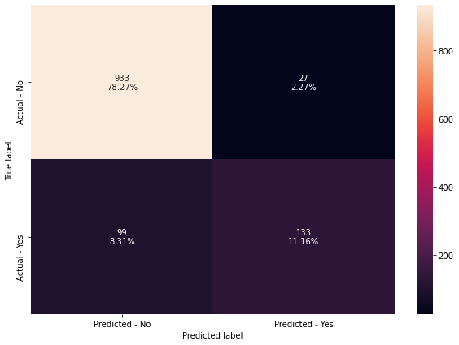

```python
confusion_matrix_sklearn(bagging, y_test)
```

```python
bagging_model_train_perf=model_performance_classification_sklearn(bagging, X_train, y_train)
print("Training performance \n",bagging_model_train_perf)
```

```
Training performance
    Accuracy    Recall  Precision        F1
0   0.99173  0.961111   0.996161  0.978322
```

```python
bagging_model_test_perf=model_performance_classification_sklearn(bagging, X_test, y_test)
print("Testing performance \n",bagging_model_test_perf)
```

```
Testing performance
    Accuracy    Recall  Precision        F1
0  0.894295  0.573276    0.83125  0.678571
```

#### Bagging Classifier Hyperparameter Tuning:

```python
# Choose the type of classifier.
bagging_estimator_tuned = BaggingClassifier(random_state=1)

# Grid of parameters to choose from
## add from article
parameters = {'max_samples': [0.7,0.8,0.9,1],
              'max_features': [0.7,0.8,0.9,1],
              'n_estimators' : [10,20,30,40,50],
             }

# Type of scoring used to compare parameter combinations
acc_scorer = metrics.make_scorer(metrics.recall_score)

# Run the grid search
grid_obj = GridSearchCV(bagging_estimator_tuned, parameters, scoring=acc_scorer,cv=5)
grid_obj = grid_obj.fit(X_train, y_train)

# Set the clf to the best combination of parameters
bagging_estimator_tuned = grid_obj.best_estimator_

# Fit the best algorithm to the data.
bagging_estimator_tuned.fit(X_train, y_train)
```

```
BaggingClassifier(max_features=0.9, max_samples=0.9, n_estimators=40,
                  random_state=1)
```

```
Accuracy on training set :  0.9992808342322905
Accuracy on test set :  0.9161073825503355
Recall on training set :  0.9962962962962963
Recall on test set :  0.6422413793103449
Precision on training set :  1.0
Precision on test set :  0.8975903614457831
```

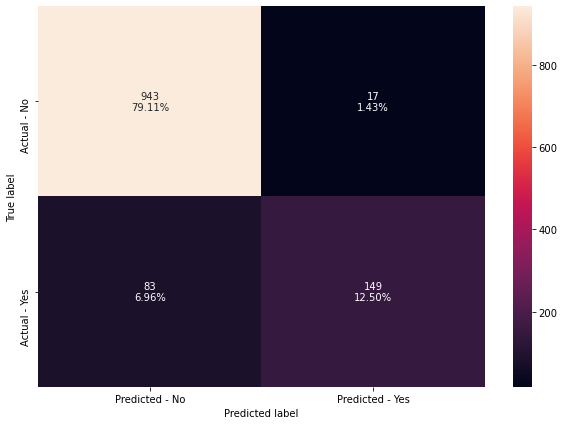

```python
#Using above defined function to get accuracy, recall and precision on train and test set
bagging_estimator_tuned_score=get_metrics_score(bagging_estimator_tuned)

confusion_matrix_sklearn(bagging_estimator_tuned,y_test)
```

-slight improvement

**Let's check different metrics for bagging classifier with best hyperparameters and build a confusion matrix.**

#### Let's try using logistic regression as the base estimator for bagging classifier:

- Now, let's try and change the `base_estimator` of the bagging classifier, which is a decision tree by default.
- We will pass the logistic regression as the base estimator for bagging classifier.

```
Accuracy on training set :  0.8238043869111831
Accuracy on test set :  0.8221476510067114
Recall on training set :  0.10555555555555556
Recall on test set :  0.11206896551724138
Precision on training set :  0.890625
Precision on test set :  0.8125
```

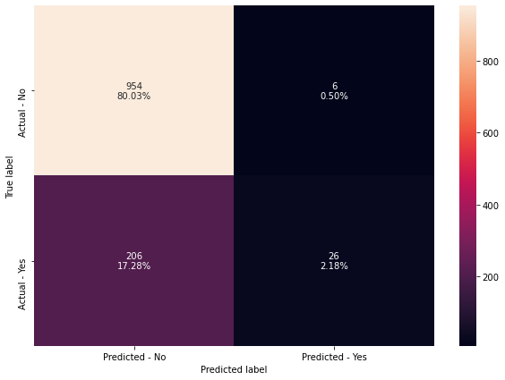

```python
bagging_lr=BaggingClassifier(base_estimator=LogisticRegression(solver='liblinear',random_state=1,max_iter=1000),random_state=1)
bagging_lr.fit(X_train,y_train)

#Using above defined function to get accuracy, recall and precision on train and test set
bagging_lr_score=get_metrics_score(bagging_lr)

confusion_matrix_sklearn(bagging_lr,y_test)
```

- No Improvement

#### Bagging Random Forest:

```python
#Train the random forest classifier
rf_estimator=RandomForestClassifier(random_state=1)
rf_estimator.fit(X_train,y_train)
```

```
RandomForestClassifier(random_state=1)
```

```python
#Using above defined function to get accuracy, recall and precision on train and test set
rf_estimator_score=get_metrics_score(rf_estimator)
```

```
Accuracy on training set :  1.0
Accuracy on test set :  0.9052013422818792
Recall on training set :  1.0
Recall on test set :  0.5689655172413793
Precision on training set :  1.0
Precision on test set :  0.9103448275862069
```

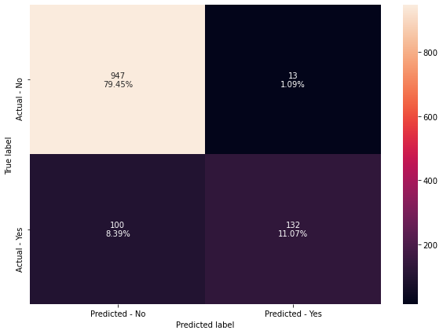

```python
confusion_matrix_sklearn(rf_estimator,y_test)
```

#### Random Forest Hyperparameter Tuning:

```python
# Choose the type of classifier.
rf_estimator_tuned = RandomForestClassifier(random_state=1)

# Grid of parameters to choose from
## add from article
parameters = {"n_estimators": [150,200,250],
    "min_samples_leaf": np.arange(5, 10),
    "max_features": np.arange(0.2, 0.7, 0.1),
    "max_samples": np.arange(0.3, 0.7, 0.1),
             }

# Type of scoring used to compare parameter combinations
acc_scorer = metrics.make_scorer(metrics.recall_score)
```

```python
# Run the grid search
grid_obj = GridSearchCV(rf_estimator_tuned, parameters, scoring=acc_scorer,cv=5)
```

```python
grid_obj = grid_obj.fit(X_train, y_train)
```

```python
# Set the clf to the best combination of parameters
rf_estimator_tuned = grid_obj.best_estimator_
```

```python
# Fit the best algorithm to the data.
rf_estimator_tuned.fit(X_train, y_train)

#Using above defined function to get accuracy, recall and precision on train and test set
rf_estimator_tuned_score=get_metrics_score(rf_estimator_tuned)
```

```
Accuracy on training set :  0.9061488673139159
Accuracy on test set :  0.8531879194630873
Recall on training set :  0.5574074074074075
Recall on test set :  0.3620689655172414
Precision on training set :  0.9318885448916409
Precision on test set :  0.7567567567567568
```

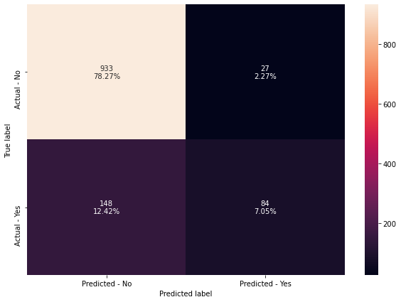

```python
confusion_matrix_sklearn(rf_estimator_tuned,y_test)
```

- No Improvement

```python
rf_estimator_tuned_model_train_perf=model_performance_classification_sklearn(rf_estimator_tuned,X_train,y_train)
print("Training performance \n",rf_estimator_tuned_model_train_perf)
```

```
Training performance
    Accuracy    Recall  Precision        F1
0  0.906149  0.557407   0.931889  0.697567
```

```python
rf_estimator_tuned_model_test_perf=model_performance_classification_sklearn(rf_estimator_tuned,X_test,y_test)
print("Testing performance \n",rf_estimator_tuned_model_test_perf)
```

```
Testing performance
    Accuracy    Recall  Precision        F1
0  0.853188  0.362069   0.756757  0.489796
```

#### Bagging Decision Tree:

Explain important data:

```python
dtree=DecisionTreeRegressor(random_state=1)
dtree.fit(X_train,y_train)
```

```
DecisionTreeRegressor(random_state=1)
```

```python
from sklearn.metrics import r2_score, mean_squared_error, mean_absolute_error

dtree_model_test_perf=model_performance_regression(dtree, X_test,y_test)
print("Testing performance \n",dtree_model_test_perf)

dtree.fit(X_train, y_train)
```

```
Testing performance
        RMSE       MAE  R-squared  Adj. R-squared  MAPE
0  0.327693  0.107383   0.314943        0.298449   inf
```

```
DecisionTreeRegressor(random_state=1)
```

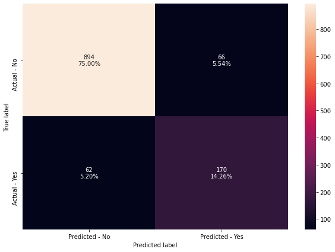

```python
confusion_matrix_sklearn(dtree, y_test)
```

#### Decision Tree Hyperparameter Tuning:

```python
# Choose the type of classifier.
dtree_tuned = DecisionTreeRegressor(random_state=1)

# Grid of parameters to choose from
parameters = {'max_depth': list(np.arange(2,20)) + [None],
              'min_samples_leaf': [1, 3, 5, 7, 10],
              'max_leaf_nodes' : [2, 3, 5, 10, 15] + [None],
              'min_impurity_decrease': [0.001, 0.01, 0.1, 0.0]
             }

# Type of scoring used to compare parameter combinations
scorer = metrics.make_scorer(metrics.r2_score)

# Run the grid search
grid_obj = GridSearchCV(dtree_tuned, parameters, scoring=scorer,cv=5)
grid_obj = grid_obj.fit(X_train, y_train)

# Set the clf to the best combination of parameters
dtree_tuned = grid_obj.best_estimator_

# Fit the best algorithm to the data.
dtree_tuned.fit(X_train, y_train)
```

```
DecisionTreeRegressor(max_depth=7, min_samples_leaf=5, random_state=1)
```

```python
dtree_tuned_model_train_perf=model_performance_regression(dtree_tuned, X_train,y_train)
```

```python
print("Training performance \n",dtree_tuned_model_train_perf)
```

```
Training performance
        RMSE       MAE  R-squared  Adj. R-squared  MAPE
0  0.287939  0.165817   0.470134        0.464742   inf
```

- Since R2 is above 0.25, the assosaition got larger.

[figure not shown]

```python
confusion_matrix_sklearn(dtree_estimator, y_test)
```

### Model building - Boosting:

#### Adaboost:

```python
ab_regressor=AdaBoostRegressor(random_state=1)
ab_regressor.fit(X_train,y_train)
```

```
AdaBoostRegressor(random_state=1)
```

```python
ab_regressor_model_train_perf = model_performance_regression(ab_regressor, X_train,y_train)
print("Training performance \n",ab_regressor_model_train_perf)
```

```
Training performance
        RMSE       MAE  R-squared  Adj. R-squared  MAPE
0  0.353823  0.293928   0.199912        0.191772   inf
```

```python
ab_regressor_model_test_perf = model_performance_regression(ab_regressor, X_test,y_test)
print("Testing performance \n",ab_regressor_model_test_perf)
```

```
Testing performance
        RMSE       MAE  R-squared  Adj. R-squared  MAPE
0  0.360523  0.298204   0.170801        0.150838   inf
```

- model is moderatly fitted

### Hyperparameter Tuning Adaboost:

```python
# Choose the type of classifier.
ab_tuned = AdaBoostRegressor(random_state=1)

# Grid of parameters to choose from
parameters = {'n_estimators': np.arange(10,100,10),
              'learning_rate': [1, 0.1, 0.5, 0.01],
              }

# Type of scoring used to compare parameter combinations
scorer = metrics.make_scorer(metrics.r2_score)

# Run the grid search
grid_obj = GridSearchCV(ab_tuned, parameters, scoring=scorer,cv=5)
grid_obj = grid_obj.fit(X_train, y_train)

# Set the clf to the best combination of parameters
ab_tuned = grid_obj.best_estimator_

# Fit the best algorithm to the data.
ab_tuned.fit(X_train, y_train)
```

```
AdaBoostRegressor(learning_rate=0.01, n_estimators=80, random_state=1)
```

```python
ab_tuned_model_train_perf = model_performance_regression(ab_tuned, X_train,y_train)
print("Training performance \n",ab_tuned_model_train_perf)
```

```
Training performance
        RMSE       MAE  R-squared  Adj. R-squared  MAPE
0  0.349253  0.257522   0.220443        0.212512   inf
```

```python
ab_tuned_model_test_perf = model_performance_regression(ab_tuned, X_test,y_test)
print("Testing performance \n",ab_tuned_model_train_perf)
```

```
Testing performance
        RMSE       MAE  R-squared  Adj. R-squared  MAPE
0  0.349253  0.257522   0.220443        0.212512   inf
```

```python
# importance of features in the tree building

print(pd.DataFrame(ab_tuned.feature_importances_, columns = ["Imp"], index = X_train.columns).sort_values(by = 'Imp', ascending = False))
```

```
                                  Imp
Passport                     0.317128
Designation_Executive        0.272514
Age                          0.171347
DurationOfPitch              0.044699
CityTier                     0.038181
NumberOfFollowups            0.030723
Occupation_Large Business    0.026611
MonthlyIncome                0.026257
PitchSatisfactionScore       0.021445
PreferredPropertyStar        0.017766
MaritalStatus_Single         0.014561
MaritalStatus_Married        0.004008
NumberOfTrips                0.003857
Gender_Male                  0.003823
NumberOfPersonVisiting       0.003099
MaritalStatus_Unmarried      0.001421
Designation_Senior Manager   0.001321
ProductPitched_Standard      0.000675
TypeofContact_Self Enquiry   0.000564
Designation_Manager          0.000000
Occupation_Salaried          0.000000
ProductPitched_Super Deluxe  0.000000
ProductPitched_King          0.000000
ProductPitched_Deluxe        0.000000
Occupation_Small Business    0.000000
NumberOfChildrenVisiting     0.000000
OwnCar                       0.000000
Designation_VP               0.000000
```

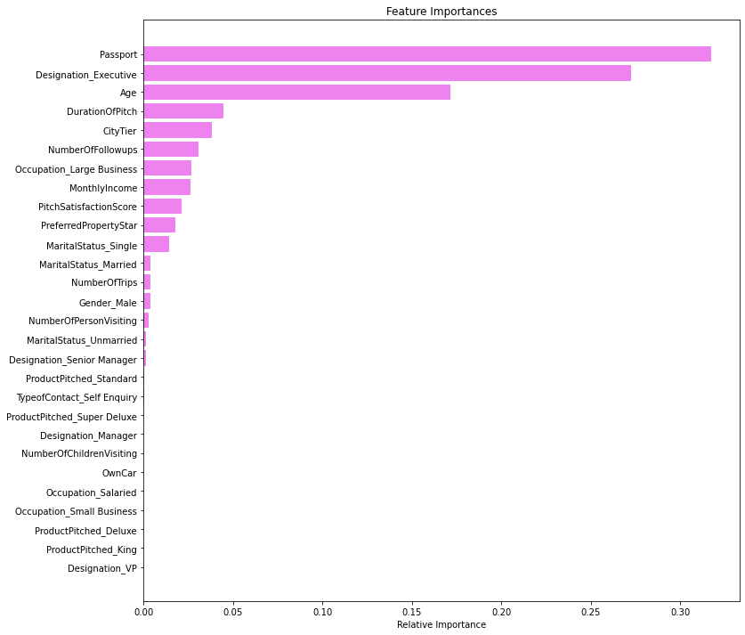

```python
feature_names = X_train.columns
importances = ab_tuned.feature_importances_
indices = np.argsort(importances)

plt.figure(figsize=(12,12))
plt.title('Feature Importances')
plt.barh(range(len(indices)), importances[indices], color='violet', align='center')
plt.yticks(range(len(indices)), [feature_names[i] for i in indices])
plt.xlabel('Relative Importance')
plt.show()
```

-Just like the heat-map, passport is the most important trait.

#### Gradient Boosting Regressor

```python
gb_estimator=GradientBoostingRegressor(random_state=1)
gb_estimator.fit(X_train,y_train)
```

```
GradientBoostingRegressor(random_state=1)
```

```python
gb_estimator_model_train_perf = model_performance_regression(gb_estimator, X_train,y_train)
print("Training performance \n",gb_estimator_model_train_perf)
```

```
Training performance
        RMSE       MAE  R-squared  Adj. R-squared  MAPE
0  0.291012  0.200536   0.458762        0.453255   inf
```

```python
gb_estimator_model_test_perf = model_performance_regression(gb_estimator, X_test, y_test)
print("Testing performance \n",gb_estimator_model_test_perf)
```

```
Testing performance
        RMSE       MAE  R-squared  Adj. R-squared  MAPE
0  0.323144  0.221653   0.333829        0.317791   inf
```

#### Hyperparameter Tuning Gradient Boosting Regressor:

```python
# # Choose the type of classifier.
# gb_tuned = GradientBoostingRegressor(random_state=1)

# # Grid of parameters to choose from
# parameters = {'n_estimators': np.arange(50,200,25),
#               'subsample':[0.7,0.8,0.9,1],
#               'max_features':[0.7,0.8,0.9,1],
#               'max_depth':[3,5,7,10]
#               }

# # Type of scoring used to compare parameter combinations
# scorer = metrics.make_scorer(metrics.r2_score)

# # Run the grid search
# grid_obj = GridSearchCV(gb_tuned, parameters, scoring=scorer,cv=5)
# grid_obj = grid_obj.fit(X_train, y_train)

# # Set the clf to the best combination of parameters
# gb_tuned = grid_obj.best_estimator_

# # Fit the best algorithm to the data.
# gb_tuned.fit(X_train, y_train)
```

-taking to long to run

```python
# gb_tuned_model_train_perf = model_performance_regression(gb_tuned, X_train,y_train)
# print("Training performance \n",gb_tuned_model_train_perf)
```

```python
# gb_tuned_model_test_perf = model_performance_regression(gb_tuned, X_test, y_test)
# print("Testing performance \n",gb_tuned_model_test_perf)
```

```python
# importance of features in the tree building ( The importance of a feature is computed as the
#(normalized) total reduction of the criterion brought by that feature. It is also known as the Gini importance )

print(pd.data(gb_tuned.feature_importances_, columns = ["Imp"], index = X_train.columns).sort_values(by = 'Imp', ascending = False))
```

[output not shown]

#### XGBoost:

```python
xgb_estimator=XGBRegressor(random_state=1)
xgb_estimator.fit(X_train,y_train)
```

```
XGBRegressor(base_score=0.5, booster='gbtree', colsample_bylevel=1,
             colsample_bynode=1, colsample_bytree=1, enable_categorical=False,
             gamma=0, gpu_id=-1, importance_type=None,
             interaction_constraints='', learning_rate=0.300000012,
             max_delta_step=0, max_depth=6, min_child_weight=1, missing=nan,
             monotone_constraints='()', n_estimators=100, n_jobs=16,
             num_parallel_tree=1, predictor='auto', random_state=1, reg_alpha=0,
             reg_lambda=1, scale_pos_weight=1, subsample=1, tree_method='exact',
             validate_parameters=1, verbosity=None)
```

```python
xgb_estimator_model_train_perf = model_performance_regression(xgb_estimator, X_train, y_train)
print("Training performance \n",xgb_estimator_model_train_perf)
```

```
Training performance
        RMSE       MAE  R-squared  Adj. R-squared  MAPE
0  0.061086  0.039282   0.976152         0.97591   inf
```

```python
xgb_estimator_model_test_perf = model_performance_regression(xgb_estimator, X_test,y_test)
print("Testing performance \n",xgb_estimator_model_test_perf)
```

```
Testing performance
        RMSE       MAE  R-squared  Adj. R-squared  MAPE
0  0.254474  0.153481   0.586877        0.576931   inf
```

#### Hyperparameter Tuning XGBoost:

- took too long to run

```python
# # Choose the type of classifier.
# xgb_tuned = XGBRegressor(random_state=1)

# # Grid of parameters to choose from
# parameters = {'n_estimators': [75,100,125,150],
#               'subsample':[0.7, 0.8, 0.9, 1],
#               'gamma':[0, 1, 3, 5],
#               'colsample_bytree':[0.7, 0.8, 0.9, 1],
#               'colsample_bylevel':[0.7, 0.8, 0.9, 1]
#               }

# # Type of scoring used to compare parameter combinations
# scorer = metrics.make_scorer(metrics.r2_score)

# # Run the grid search
# grid_obj = GridSearchCV(xgb_tuned, parameters, scoring=scorer,cv=5)
# grid_obj = grid_obj.fit(X_train, y_train)

# # Set the clf to the best combination of parameters
# xgb_tuned = grid_obj.best_estimator_

# # Fit the best algorithm to the data.
# xgb_tuned.fit(X_train, y_train)
```

```python
# xgb_tuned_model_train_perf = model_performance_regression(xgb_tuned, X_train, y_train)
# print("Training performance \n",xgb_tuned_model_train_perf)
```

```python
# xgb_tuned_model_test_perf = model_performance_regression(xgb_tuned, X_test, y_test)
# print("Testing performance \n",xgb_tuned_model_test_perf)
```

```python
# # importance of features in the tree building ( The importance of a feature is computed as the
# #(normalized) total reduction of the criterion brought by that feature. It is also known as the Gini importance )

# print(pd.data(xgb_tuned.feature_importances_, columns = ["Imp"], index = X_train.columns).sort_values(by = 'Imp', ascending = False))
```

```python
# feature_names = X_train.columns
# importances = xgb_tuned.feature_importances_
# indices = np.argsort(importances)

# plt.figure(figsize=(12,12))
# plt.title('Feature Importances')
# plt.barh(range(len(indices)), importances[indices], color='violet', align='center')
# plt.yticks(range(len(indices)), [feature_names[i] for i in indices])
# plt.xlabel('Relative Importance')
# plt.show()
```

#### Stacking Classifiers:

```python
estimators = [('Random Forest',rf_estimator_tuned_model_test_perf), ('Gradient Boosting',gb_estimator_model_test_perf), ('Decision Tree',dtree_model_test_perf)]
```

```python
final_estimator = xgb_estimator_model_test_perf
```

```python
DataFrame= DataFrame.any()
```

```python
StackingClassifier(estimators=estimators,final_estimator=final_estimator).fit(X_train,y_train)
```

[output not shown]

```python
#Calculating different metrics
stacking_classifier_model_train_perf=model_performance_classification_sklearn(stacking_classifier,X_train,y_train)
print("Training performance:\n",stacking_classifier_model_train_perf)
stacking_classifier_model_test_perf=model_performance_classification_sklearn(stacking_classifier,X_test,y_test)
print("Testing performance:\n",stacking_classifier_model_test_perf)

#Creating confusion matrix
confusion_matrix_sklearn(stacking_classifier,X_test,y_test)
```

[output not shown]

### Recommendations

Next marketing campaign, target those with passports only. Then it will become clearer what marketing improvements can be made after.Targeting those with passports should also increase the sales. Unfortunately, the traits in the previous study had little effect on passport. The Wellness Tourism Package should be pitched the most to get it to sell. Information on returning clients for the previouse packages purchased should be recorded.